# Assignment 2- Universal bank

Usha Pedapudi

2029-09-29

##Problem Statement - Universal Bank, with a predominantly liability customer base, aims to expand its asset customer segment by converting liability customers to personal loan customers. Leveraging k-NN, the goal is to predict the acceptance of a loan offer by new customers. ***

#####Installing and loading a few packages which are required:

```r
library(class)
library(caret)
library(e1071)
```

####Setting the working directory and Importing the data to R

```r
setwd("~/FML/UP assignment 2")
u_bank_data = read.csv("./UniversalBank.csv")
dim(u_bank_data)
```

```
## [1] 5000   14
```

```r
t(t(names(u_bank_data))) # The 't' function is used to a transpose the dataframe
```

```
##       [,1]
##  [1,] "ID"
##  [2,] "Age"
##  [3,] "Experience"
##  [4,] "Income"
##  [5,] "ZIP.Code"
##  [6,] "Family"
##  [7,] "CCAvg"
##  [8,] "Education"
##  [9,] "Mortgage"
## [10,] "Personal.Loan"
## [11,] "Securities.Account"
## [12,] "CD.Account"
## [13,] "Online"
## [14,] "CreditCard"
```

####Removing Unwanted Items which are ID and ZIP Code

```r
u_bank_data <- u_bank_data[,-c(1,5)]
head(u_bank_data)
```

```
##   Age Experience Income Family CCAvg Education Mortgage Personal.Loan
## 1  25          1     49      4   1.6         1        0             0
## 2  45         19     34      3   1.5         1        0             0
## 3  39         15     11      1   1.0         1        0             0
## 4  35          9    100      1   2.7         2        0             0
## 5  35          8     45      4   1.0         2        0             0
## 6  37         13     29      4   0.4         2      155             0
##   Securities.Account CD.Account Online CreditCard
## 1                  1          0      0          0
## 2                  1          0      0          0
## 3                  0          0      0          0
## 4                  0          0      0          0
## 5                  0          0      0          1
## 6                  0          0      1          0
```

####Transforming categorical variables into dummy variables

```r
u_bank_data$Education <- as.factor(u_bank_data$Education) #Education is being converted into factor
levels(u_bank_data$Education)
```

```
## [1] "1" "2" "3"
```

####Now converting Education into dummy variables.

```r
edu_dummy <- dummyVars(~., data = u_bank_data) #Converting Education into Dummy Variables
unibank234<- as.data.frame(predict(edu_dummy,u_bank_data))
head(unibank234)
```

```
##   Age Experience Income Family CCAvg Education.1 Education.2 Education.3
## 1  25          1     49      4   1.6           1           0           0
## 2  45         19     34      3   1.5           1           0           0
## 3  39         15     11      1   1.0           1           0           0
## 4  35          9    100      1   2.7           0           1           0
## 5  35          8     45      4   1.0           0           1           0
## 6  37         13     29      4   0.4           0           1           0
##   Mortgage Personal.Loan Securities.Account CD.Account Online CreditCard
## 1        0             0                  1          0      0          0
## 2        0             0                  1          0      0          0
## 3        0             0                  0          0      0          0
## 4        0             0                  0          0      0          0
## 5        0             0                  0          0      0          1
## 6      155             0                  0          0      1          0
```

####Checking the sample:

```r
set.seed(1)
train <-sample(row.names(u_bank_data),0.6*dim(unibank234)[1])
valid<- setdiff(row.names(unibank234), train)
train.df <- unibank234[train,]
valid.df <- unibank234[valid,]
t(t(names(train.df)))
```

```
##       [,1]
##  [1,] "Age"
##  [2,] "Experience"
##  [3,] "Income"
##  [4,] "Family"
##  [5,] "CCAvg"
##  [6,] "Education.1"
##  [7,] "Education.2"
##  [8,] "Education.3"
##  [9,] "Mortgage"
## [10,] "Personal.Loan"
## [11,] "Securities.Account"
## [12,] "CD.Account"
## [13,] "Online"
## [14,] "CreditCard"
```

```r
library(caTools) #Installing package 'caTools'
set.seed(1)
split <- sample.split(unibank234, SplitRatio = 0.6)
training_set <- subset(unibank234, split == TRUE)
validation_set <- subset(unibank234, split == FALSE)
```

##### Printing the sizes of the training and validation sets

```r
print(paste("The size of the training set is:", nrow(training_set)))
```

```
## [1] "The size of the training set is: 2858"
```

```r
print(paste("The size of the validation set is:", nrow(validation_set)))
```

```
## [1] "The size of the validation set is: 2142"
```

####Normalizing the data

```r
training.norm.df <- train.df[,-10] #Personal Income is the 10th variable
validation.norm.df <- valid.df[,-10]
norm.values <- preProcess(train.df[, -10], method=c("center", "scale"))
training.norm.df <- predict(norm.values, train.df[, -10])
validation.norm.df <- predict(norm.values, valid.df[, -10])
```

####Query 1: We’re using a method (k-NN) to decide if a customer will accept a loan. Ignoring unimportant details like ID and ZIP code, we’re transforming certain preferences into a simpler form. By comparing them to similar customers (k=1), if the similarity is high (above 0.5), we predict the customer will accept the loan.

Given: Age = 40, Experience = 10, Income = 84, Family = 2, CCAvg = 2, Education_1 = 0, Education_2 = 1, Education_3 = 0, Mortgage = 0, Securities Account = 0, CD Account = 0, Online = 1, and Credit Card = 1. Perform a k-NN classification with all predictors except ID and ZIP code using k = 1.

```r
#We have transformed all categorical variables to dummy variables
test_cust <- data.frame(Age = 40,
                           Experience = 10,
                           Income = 84,
                           Family = 2,
                           CCAvg = 2,
                           Education.1 = 0,
                           Education.2 = 1,
                           Education.3 = 0,
                           Mortgage = 0,
                           Securities.Account = 0,
                           CD.Account = 0,
                           Online = 1,
                           CreditCard = 1) #Creating a new sample
```

####Normalizing test customer:

```r
test.cust.normalized<- test_cust
test.cust.normalized <- predict(norm.values, test.cust.normalized)
```

#####Using kNN to predict

```r
predict.knn_1 <- class::knn(train = training.norm.df,
                       test = test.cust.normalized,
                       cl = train.df$Personal.Loan, k = 1)
predict.knn_1
```

```
## [1] 0
## Levels: 0 1
```

####Query2 : What is a choice of k that balances between overfitting and ignoring the predictor information?

```r
#Calculating the accuracy for each value of k
accuracy.df <- data.frame(k = seq(1, 15, 1), overallaccuracy = rep(0, 15)) #Setting the range of k values to consider

for(i in 1:15) {
  predict.knn_1 <- class::knn(train = training.norm.df,
                         test = validation.norm.df,
                         cl = train.df$Personal.Loan, k = i)
  accuracy.df[i, 2] <- confusionMatrix(predict.knn_1, as.factor(valid.df$Personal.Loan),positive = "1")$overall[1]
}

which(accuracy.df[,2] == max(accuracy.df[,2]))
```

```
## [1] 3
```

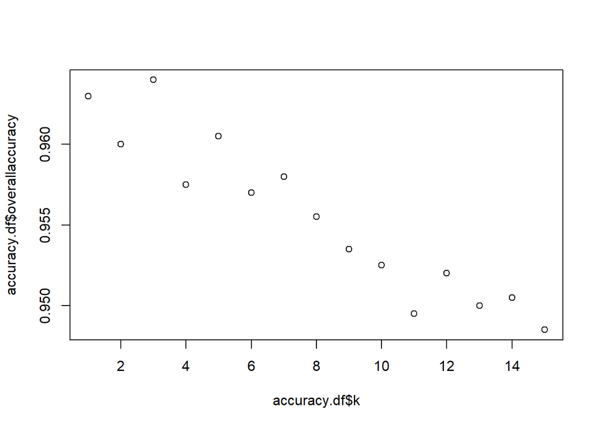

```r
plot(accuracy.df$k,accuracy.df$overallaccuracy)
```

####Query 3: Show the confusion matrix for the validation data that results from using the best k.

```r
#Using confusion matrix for the validation
predict.knn_2 <- class::knn(train = training.norm.df,
                        test = validation.norm.df,
                        cl = train.df$Personal.Loan, k = 3)

confusionMatrix(predict.knn_2,as.factor(valid.df$Personal.Loan))
```

```
## Confusion Matrix and Statistics
##
##           Reference
## Prediction    0    1
##          0 1786   63
##          1    9  142
##
##                Accuracy : 0.964
##                  95% CI : (0.9549, 0.9717)
##     No Information Rate : 0.8975
##     P-Value [Acc > NIR] : < 2.2e-16
##
##                   Kappa : 0.7785
##
##  Mcnemar's Test P-Value : 4.208e-10
##
##             Sensitivity : 0.9950
##             Specificity : 0.6927
##          Pos Pred Value : 0.9659
##          Neg Pred Value : 0.9404
##              Prevalence : 0.8975
##          Detection Rate : 0.8930
##    Detection Prevalence : 0.9245
##       Balanced Accuracy : 0.8438
##
##        'Positive' Class : 0
##
```

####Query4: Classify the customer using the best k. #####Given: Age = 40, Experience = 10, Income = 84, Family = 2, CCAvg = 2, Education_1 = 0, Education_2 = 1, Education_3 = 0,Mortgage = 0, Securities Account = 0, CD Account = 0, Online = 1 and Credit Card = 1

```r
#Classifying the test customer 2 using the best k
test_cust2 = data.frame(Age = 40,
                           Experience = 10,
                           Income = 84,
                           Family = 2,
                           CCAvg = 2,
                           Education.1 = 0,
                           Education.2 = 1,
                           Education.3 = 0,
                           Mortgage = 0,
                           Securities.Account = 0,
                           CD.Account = 0,
                           Online = 1,
                           CreditCard = 1)

predict.knn_3 <- class::knn(train = training.norm.df,
                         test = test_cust2,
                         cl = train.df$Personal.Loan, k = 3)
predict.knn_3
```

```
## [1] 1
## Levels: 0 1
```

```r
#The Test customer has been classified as approved for a loan
```

```r
set.seed(2)

#Taking 50% data as Training data
train.df2 = sample(row.names(u_bank_data),0.5*dim(u_bank_data)[1])

#Taking 30% data from the remaining 50% as Validation Data
valid.df2 = sample(setdiff(row.names(u_bank_data), train.df2), 0.3*dim(u_bank_data)[1])

#Taking remaining 20% of the data as Test Data
test.df2 = setdiff(row.names(u_bank_data),union(train.df2,valid.df2))

training.norm.df2 = u_bank_data[train.df2,]
validation.norm.df2 = u_bank_data[valid.df2,]
test.norm.df2 = u_bank_data[test.df2,]

##transposing the data
t(t(names(training.norm.df2)))
```

```
##       [,1]
##  [1,] "Age"
##  [2,] "Experience"
##  [3,] "Income"
##  [4,] "Family"
##  [5,] "CCAvg"
##  [6,] "Education"
##  [7,] "Mortgage"
##  [8,] "Personal.Loan"
##  [9,] "Securities.Account"
## [10,] "CD.Account"
## [11,] "Online"
## [12,] "CreditCard"
```

```r
# Applying the k-NN method with the chosen K.
trainingknn2 = knn(train = training.norm.df2[,-8], test = training.norm.df2[,-8], cl = training.norm.df2[,8], k=3)

validationknn2 = knn(train = training.norm.df2[,-8], test = validation.norm.df2[,-8], cl = training.norm.df2[,8], k=3)

testknn2 = knn(train = training.norm.df2[,-8], test = test.norm.df2[,-8], cl = training.norm.df2[,8], k=3)
```

####Comparing the confusion matrix of the training set.

```r
Confusionmatrix_trainingknn2 = confusionMatrix(trainingknn2, as.factor(training.norm.df2$Personal.Loan),positive = "1")

Confusionmatrix_trainingknn2
```

```
## Confusion Matrix and Statistics
##
##           Reference
## Prediction    0    1
##          0 2210   86
##          1   41  163
##
##                Accuracy : 0.9492
##                  95% CI : (0.9399, 0.9575)
##     No Information Rate : 0.9004
##     P-Value [Acc > NIR] : < 2.2e-16
##
##                   Kappa : 0.692
##
##  Mcnemar's Test P-Value : 9.447e-05
##
##             Sensitivity : 0.6546
##             Specificity : 0.9818
##          Pos Pred Value : 0.7990
##          Neg Pred Value : 0.9625
##              Prevalence : 0.0996
##          Detection Rate : 0.0652
##    Detection Prevalence : 0.0816
##       Balanced Accuracy : 0.8182
##
##        'Positive' Class : 1
##
```

```r
Confusionmatrix_validationknn2 = confusionMatrix(validationknn2, as.factor(validation.norm.df2$Personal.Loan),positive = "1")

Confusionmatrix_trainingknn2
```

```
## Confusion Matrix and Statistics
##
##           Reference
## Prediction    0    1
##          0 2210   86
##          1   41  163
##
##                Accuracy : 0.9492
##                  95% CI : (0.9399, 0.9575)
##     No Information Rate : 0.9004
##     P-Value [Acc > NIR] : < 2.2e-16
##
##                   Kappa : 0.692
##
##  Mcnemar's Test P-Value : 9.447e-05
##
##             Sensitivity : 0.6546
##             Specificity : 0.9818
##          Pos Pred Value : 0.7990
##          Neg Pred Value : 0.9625
##              Prevalence : 0.0996
##          Detection Rate : 0.0652
##    Detection Prevalence : 0.0816
##       Balanced Accuracy : 0.8182
##
##        'Positive' Class : 1
##
```

```r
Confusionmatrix_testknn2 = confusionMatrix(testknn2, as.factor(test.norm.df2$Personal.Loan),positive = "1")

Confusionmatrix_trainingknn2
```

```
## Confusion Matrix and Statistics
##
##           Reference
## Prediction    0    1
##          0 2210   86
##          1   41  163
##
##                Accuracy : 0.9492
##                  95% CI : (0.9399, 0.9575)
##     No Information Rate : 0.9004
##     P-Value [Acc > NIR] : < 2.2e-16
##
##                   Kappa : 0.692
##
##  Mcnemar's Test P-Value : 9.447e-05
##
##             Sensitivity : 0.6546
##             Specificity : 0.9818
##          Pos Pred Value : 0.7990
##          Neg Pred Value : 0.9625
##              Prevalence : 0.0996
##          Detection Rate : 0.0652
##    Detection Prevalence : 0.0816
##       Balanced Accuracy : 0.8182
##
##        'Positive' Class : 1
##
```